# Supervised Learning - Foundations Project: ReCell

### Dealing with high p-value variables

- Some of the dummy variables in the data have p-value > 0.05. So, they are not significant and we'll drop them
- But sometimes p-values change after dropping a variable. So, we'll not drop all variables at once
- Instead, we will do the following:
  - Build a model, check the p-values of the variables, and drop the column with the highest p-value
  - Create a new model without the dropped feature, check the p-values of the variables, and drop the column with the highest p-value
  - Repeat the above two steps till there are no columns with p-value > 0.05

```python
# Code snippet provided by GreatLearning; SLF_MLS2_AnimeRatings python file.
# initial list of columns
predictors = x_train3.copy()
cols = predictors.columns.tolist()

# setting an initial max p-value
max_p_value = 1

while len(cols) > 0:
    # defining the train set
    x_train_aux = predictors[cols]

    # fitting the model
    model = sm.OLS(y_train, x_train_aux).fit()

    # getting the p-values and the maximum p-value
    p_values = model.pvalues
    max_p_value = max(p_values)

    # name of the variable with maximum p-value
    feature_with_p_max = p_values.idxmax()

    if max_p_value > 0.05:
        cols.remove(feature_with_p_max)
    else:
        break

selected_features = cols
print("The following features have been selected to keep:")
print(selected_features)
```

```
The following features have been selected to keep:
['const', 'screen_size', 'main_camera_mp', 'selfie_camera_mp', 'ram', 'days_used', 'normalized_new_price', 'years_since_release', 'brand_name_Lenovo', 'brand_name_Nokia', 'brand_name_Xiaomi', '4g_yes']
```

Now that features have been dropped due to the p(t) > .05 test, we can now rerun the model with the remaining features.

```python
# Create new X training and X test dataFrames from the selected features only
x_train4 = x_train3[selected_features]
x_test4 = x_test3[selected_features]

# Quick visual to verify only selected features are being displayed
print (x_train4.head())
print ('\n')
print (x_test4.head())
```

```
        const  screen_size  main_camera_mp  selfie_camera_mp      ram  \
3026 1.000000    10.290000        8.000000          0.300000 4.000000
1525 1.000000    15.340000       13.000000          5.000000 4.000000
1128 1.000000    12.700000       13.000000          5.000000 4.000000
3003 1.000000    12.830000        8.000000          5.000000 4.000000
2907 1.000000    12.880000       13.000000         16.000000 4.000000

      days_used  normalized_new_price  years_since_release  brand_name_Lenovo  \
3026        819              4.796204                    7                  0
1525        585              5.434595                    5                  1
1128        727              5.137914                    6                  0
3003        800              5.189228                    6                  0
2907        560              5.016220                    4                  0

      brand_name_Nokia  brand_name_Xiaomi  4g_yes
```

[output cut: 27 more lines]

```python
# Create a new model using the latest x_train dataFrame
olsmodel2 = sm.OLS(y_train, x_train4).fit()
print(olsmodel2.summary())
```

```
                              OLS Regression Results
=================================================================================
Dep. Variable:     normalized_used_price   R-squared:                       0.839
Model:                               OLS   Adj. R-squared:                  0.839
Method:                    Least Squares   F-statistic:                     1142.
Date:                   Fri, 22 Mar 2024   Prob (F-statistic):               0.00
Time:                           15:32:33   Log-Likelihood:                 81.071
No. Observations:                   2417   AIC:                            -138.1
Df Residuals:                       2405   BIC:                            -68.66
Df Model:                             11
Covariance Type:               nonrobust
========================================================================================
                           coef    std err          t      P>|t|      [0.025      0.975]
----------------------------------------------------------------------------------------
const                    1.2119      0.046     26.274      0.000       1.121       1.302
screen_size              0.0433      0.002     28.306      0.000       0.040       0.046
main_camera_mp           0.0189      0.001     13.938      0.000       0.016       0.022
selfie_camera_mp         0.0131      0.001     12.372      0.000       0.011       0.015
ram                      0.0172      0.004      3.914      0.000       0.009       0.026
days_used             6.226e-05   3.03e-05      2.052      0.040    2.75e-06       0.000
normalized_new_price     0.4282      0.011     39.576      0.000       0.407       0.449
years_since_release     -0.0181      0.004     -4.184      0.000      -0.027      -0.010
brand_name_Lenovo        0.0489      0.022      2.261      0.024       0.006       0.091
brand_name_Nokia         0.0733      0.030      2.458      0.014       0.015       0.132
brand_name_Xiaomi        0.0852      0.026      3.320      0.001       0.035       0.135
4g_yes                   0.0369      0.015      2.456      0.014       0.007       0.066
==============================================================================
Omnibus:                      217.147   Durbin-Watson:                   1.916
Prob(Omnibus):                  0.000   Jarque-Bera (JB):              403.764
Skew:                          -0.610   Prob(JB):                     2.11e-88
Kurtosis:                       4.588   Cond. No.                     7.13e+03
==============================================================================

Notes:
[1] Standard Errors assume that the covariance matrix of the errors is correctly specified.
[2] The condition number is large, 7.13e+03. This might indicate that there are
strong multicollinearity or other numerical problems.
```

#### Summary

- $R^2$ value is still good at a value of 0.83.
- All P>|t| are <= .05
- Let's now check the model performance between the Training and Test data to ensure the metrics are within reason of eachother.
- Need to ensure there is over fitting between the train and test data.

```python
# checking model performance on train set (seen 70% data)
print("Model Training Performance\n")
olsmod2_train_perf = model_performance_regression(olsmodel2, x_train4, y_train)
olsmod2_train_perf
```

```
Model Training Performance
```

|  | RMSE | MAE | R-squared | Adj. R-squared | MAPE |
| --- | --- | --- | --- | --- | --- |
| 0 | 0.233989 | 0.183177 | 0.839296 | 0.838494 | 4.392265 |

```python
# checking model performance on test set (seen 30% data)
print("Model Test Performance\n")
olsmod2_test_perf = model_performance_regression(olsmodel2, x_test4, y_test)
olsmod2_test_perf
```

```
Model Test Performance
```

|  | RMSE | MAE | R-squared | Adj. R-squared | MAPE |
| --- | --- | --- | --- | --- | --- |
| 0 | 0.238554 | 0.185000 | 0.842220 | 0.840371 | 4.500963 |

**Observations**

**Now we'll check the rest of the assumptions on *olsmodel2*.**

1. **Linearity of variables**
2. **Independence of error terms**
3. **Normality of error terms**
4. **No Heteroscedasticity**

### Testing Linearity of Variables

- Test for linearity and independence by making a plot of fitted values vs residuals and checking for patterns.
- If there is no pattern, then we say the model is linear and residuals are independent.
- Otherwise, the model is showing signs of non-linearity and residuals are not independent.

```python
# let us create a dataframe with actual, fitted and residual values
df_pred = pd.DataFrame()

df_pred["Actual Values"] = y_train  # actual values
df_pred["Fitted Values"] = olsmodel2.fittedvalues  # predicted values
df_pred["Residuals"] = olsmodel2.resid  # residuals

#Show a few rows to verify everything is correct
df_pred.head()
```

|  | Actual Values | Fitted Values | Residuals |
| --- | --- | --- | --- |
| 3026 | 4.087488 | 3.858599 | 0.228888 |
| 1525 | 4.448399 | 4.613833 | -0.165434 |
| 1128 | 4.315353 | 4.277568 | 0.037785 |
| 3003 | 4.282068 | 4.252225 | 0.029844 |
| 2907 | 4.456438 | 4.440283 | 0.016156 |

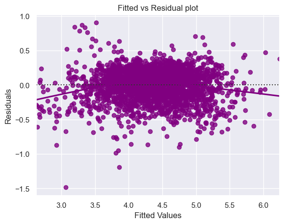

```python
# let's plot the fitted values vs residuals

sns.residplot(
    data=df_pred, x="Fitted Values", y="Residuals", color="purple", lowess=True
)
plt.xlabel("Fitted Values")
plt.ylabel("Residuals")
plt.title("Fitted vs Residual plot")
plt.show()
```

#### Observations

- The scatter plot shows the distribution of residuals (errors) vs fitted values (predicted values).
- We see no significant pattern in the plot above.
- **Hence, the assumptions of linearity and independence are satisfied.**

### TEST FOR NORMALITY

- There are three (3) common ways to test for normality
  - Histogram plot
  - Q-Q plot
  - Shapiro-Wilk Test

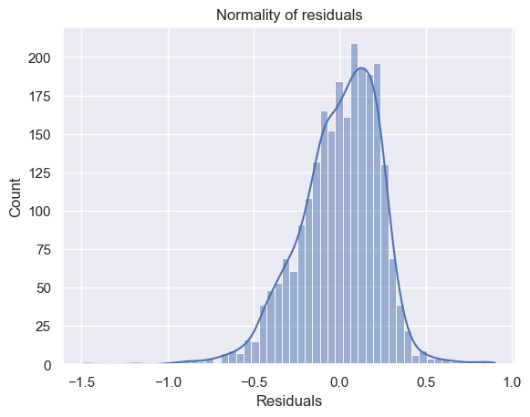

```python
# Normality Method 1: Histogram plot
sns.histplot(data=df_pred, x="Residuals", kde=True)
plt.title("Normality of residuals")
plt.show()
```

#### Observation:

- The histogram plot visually resembles a normal distribution.

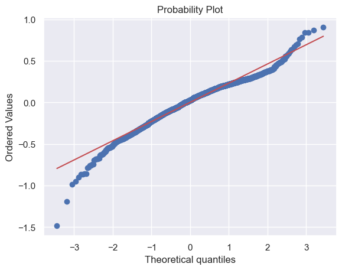

```python
# Normality Method 2: Q-Q plot
import pylab
import scipy.stats as stats

# Create the Q-Q plot for the residuals
stats.probplot(df_pred["Residuals"], dist="norm", plot=pylab)
plt.show()
```

#### Observation

- Overall, the Q-Q plot shows normal distribution; except some non-normalcy at the tail-ends.
- Let's check the Shapiro-Wilk Test
  - Null hypothesis: Residuals are normally distributed
  - Alternate hypothesis: Residuals are not normally distributed

```python
# Normality Method 3: Shapiro-Wilk Test
stats.shapiro(df_pred["Residuals"])
```

```
ShapiroResult(statistic=0.9724023342132568, pvalue=3.463951697107566e-21)
```

#### Observation

- Since the p-value <= .05, there is enough statisfical evidence to reject the Null Hypothesis.
- Therefore, the residuals do not follow a normal distribution.
- However, as an approximation, we can accept this distribution as close to being normal.
- **So, the assumption or Normalcy is satisfied.**

### TEST FOR HOMOSCEDASTICITY

- Terminology:
  - **Homoscedascity**: If the variance of the residuals is symmetrically distributed across the regression line, then the data is said to be homoscedastic.
  - **Heteroscedascity**: If the variance is unequal for the residuals across the regression line, then the data is said to be heteroscedastic.
    - Common Tests for Homoscedasticity
    - Scatter plot: Residuals vs Fitted values
    - goldfeldquandt test
      - $H_0$ (Null hypothesis): Residuals are homoscedastic
      - $H_a$ (Alternate hypothesis): Residuals have heteroscedasticity

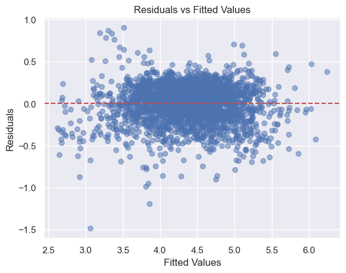

```python
# Create scatterplot= Residuals vs Fitted values
import matplotlib.pyplot as plt
# Create a scatter plot
plt.scatter(df_pred["Fitted Values"], df_pred["Residuals"], alpha=0.5)

# Add labels and title
plt.title('Residuals vs Fitted Values')
plt.xlabel('Fitted Values')
plt.ylabel('Residuals')

# Add a horizontal line at y=0 for reference
plt.axhline(y=0, color='r', linestyle='--')
```

#### Observation

- The residuals are relatively symmetrical across the residual line.

```python
# Apply the goldfeldquandt test
import statsmodels.stats.api as sms
from statsmodels.compat import lzip

name = ["F statistic", "p-value"]
test = sms.het_goldfeldquandt(df_pred["Residuals"], x_train4)
lzip(name, test)
```

```
[('F statistic', 1.0554902509992028), ('p-value', 0.17520491832996798)]
```

#### Observation

- Since the p-value is not less then .05, there is not enough statistical evidence to reject the Null Hypothesis.
- Therefore, the residuals are homoscedastic
- **The assumption of homoscedastic is satisfied.**

### Test Predictions

- Now that the assumptions are satisfied, let's do a quick check on predicted values

```python
# predictions on the test set
pred = olsmodel2.predict(x_test4)

df_pred_test = pd.DataFrame({"Actual": y_test, "Predicted": pred})
df_pred_test.sample(15, random_state=1)
```

|  | Actual | Predicted |
| --- | --- | --- |
| 1995 | 4.566741 | 4.370046 |
| 2341 | 3.696103 | 3.954403 |
| 1913 | 3.592093 | 3.760742 |
| 688 | 4.306495 | 4.099280 |
| 650 | 4.522115 | 5.117977 |
| 2291 | 4.259294 | 4.392088 |
| 40 | 4.997685 | 5.404365 |
| 1884 | 3.875359 | 4.103732 |
| 2538 | 4.206631 | 4.044604 |
| 45 | 5.380450 | 5.301336 |
| 553 | 3.215671 | 3.390670 |
| 3229 | 4.652531 | 4.718912 |
| 1892 | 4.812428 | 4.568803 |
| 1696 | 3.909219 | 4.082258 |
| 3254 | 5.179534 | 5.343544 |

## Final Model

```python
# Print out the model equation; Code snippet provided by GreatLearning with minor modifications
Equation = "normalized_used_price = "
print(Equation, end=" ")
for i in range(len(x_train4.columns)):
    if i == 0:
        print(model.params[i], "+", end="\n")
    elif i != len(x_train4.columns) - 1:
        print(
            "(",
            model.params[i],
            ")*(",
            x_train4.columns[i],
            ")",
            "+\n",
            end=" ",
        )
    else:
        print("(", model.params[i], ")*(", x_train4.columns[i], ")")
```

```
normalized_used_price =  1.2118771824465957 +
( 0.04325227839850685 )*( screen_size ) +
 ( 0.01887270126675198 )*( main_camera_mp ) +
 ( 0.013121453066686752 )*( selfie_camera_mp ) +
 ( 0.017211865742470918 )*( ram ) +
 ( 6.226184812227738e-05 )*( days_used ) +
 ( 0.4281848961888851 )*( normalized_new_price ) +
 ( -0.018109095903090844 )*( years_since_release ) +
 ( 0.04889654269800811 )*( brand_name_Lenovo ) +
 ( 0.07334229761625144 )*( brand_name_Nokia ) +
 ( 0.08517107570967972 )*( brand_name_Xiaomi ) +
 ( 0.03688051823569741 )*( 4g_yes )
```

```python
# Create the final model
x_train_final = x_train4.copy()
x_test_final = x_test4.copy()

olsmodel_final = sm.OLS(y_train, x_train_final).fit()
print(olsmodel_final.summary())
```

```
                              OLS Regression Results
=================================================================================
Dep. Variable:     normalized_used_price   R-squared:                       0.839
Model:                               OLS   Adj. R-squared:                  0.839
Method:                    Least Squares   F-statistic:                     1142.
Date:                   Fri, 22 Mar 2024   Prob (F-statistic):               0.00
Time:                           15:45:46   Log-Likelihood:                 81.071
No. Observations:                   2417   AIC:                            -138.1
Df Residuals:                       2405   BIC:                            -68.66
Df Model:                             11
Covariance Type:               nonrobust
========================================================================================
                           coef    std err          t      P>|t|      [0.025      0.975]
----------------------------------------------------------------------------------------
const                    1.2119      0.046     26.274      0.000       1.121       1.302
screen_size              0.0433      0.002     28.306      0.000       0.040       0.046
main_camera_mp           0.0189      0.001     13.938      0.000       0.016       0.022
selfie_camera_mp         0.0131      0.001     12.372      0.000       0.011       0.015
ram                      0.0172      0.004      3.914      0.000       0.009       0.026
days_used             6.226e-05   3.03e-05      2.052      0.040    2.75e-06       0.000
normalized_new_price     0.4282      0.011     39.576      0.000       0.407       0.449
years_since_release     -0.0181      0.004     -4.184      0.000      -0.027      -0.010
brand_name_Lenovo        0.0489      0.022      2.261      0.024       0.006       0.091
brand_name_Nokia         0.0733      0.030      2.458      0.014       0.015       0.132
brand_name_Xiaomi        0.0852      0.026      3.320      0.001       0.035       0.135
4g_yes                   0.0369      0.015      2.456      0.014       0.007       0.066
==============================================================================
Omnibus:                      217.147   Durbin-Watson:                   1.916
Prob(Omnibus):                  0.000   Jarque-Bera (JB):              403.764
Skew:                          -0.610   Prob(JB):                     2.11e-88
Kurtosis:                       4.588   Cond. No.                     7.13e+03
==============================================================================

Notes:
[1] Standard Errors assume that the covariance matrix of the errors is correctly specified.
[2] The condition number is large, 7.13e+03. This might indicate that there are
strong multicollinearity or other numerical problems.
```

```python
# Check model performance on train set (seen 70% data)
print("Model Training Performance\n")
olsmodel_final_train_perf = model_performance_regression(
    olsmodel_final, x_train_final, y_train
)
olsmodel_final_train_perf
```

```
Model Training Performance
```

|  | RMSE | MAE | R-squared | Adj. R-squared | MAPE |
| --- | --- | --- | --- | --- | --- |
| 0 | 0.233989 | 0.183177 | 0.839296 | 0.838494 | 4.392265 |

```python
# Check model performance on test set (seen 30% data)
# checking model performance on test set (seen 30% data)
print("Test Performance\n")
olsmodel_final_test_perf = model_performance_regression(
    olsmodel_final, x_test_final, y_test
)
olsmodel_final_test_perf
```

```
Test Performance
```

|  | RMSE | MAE | R-squared | Adj. R-squared | MAPE |
| --- | --- | --- | --- | --- | --- |
| 0 | 0.238554 | 0.185000 | 0.842220 | 0.840371 | 4.500963 |